# Fitness summary

SYSTEM: R version 4.2.0 (2022-04-22)

DATE: 2022-05-13 18:24:36

# 1 Requirements

```
[1] "Missing package(s) gridExtra are installed to '/home/michael/.R'."
```

- loading libraries

```
[1] "Required package(s) dplyr, ggplot2, gridExtra are loaded."
```

# 2 Sample overview

## 2.1 Data import

- Checking if result file(s) are available:

| input_files | size | isdir | mode | mtime | uname |
| --- | --- | --- | --- | --- | --- |
| result.Rdata | 17.90628 MB | FALSE | 644 | 2022-05-13 18:24:32.573622 | michael |

- Importing result tables:

```
[1] "Import of fitness table complete."
```

## 2.2 Conditions table

| condition | time | barcodes | DESeq_baseMean | DESeq_log2FC |
| --- | --- | --- | --- | --- |
| Ala | 0 | 21470 | NaN | 0.0000000 |
| Ala | 10 | 21470 | 380.3505 | -0.1861564 |
| Arg | 0 | 21470 | NaN | 0.0000000 |
| Arg | 10 | 21470 | 380.3505 | -0.1861564 |
| Asn | 0 | 21470 | NaN | 0.0000000 |
| Asn | 10 | 21470 | 380.3505 | -0.1861564 |
| Ctr | 0 | 21470 | NaN | 0.0000000 |
| Ctr | 10 | 21470 | 380.3505 | -0.1861564 |
| Cys | 0 | 21470 | NaN | 0.0000000 |
| Cys | 10 | 21470 | 380.3505 | -0.1861564 |

[output cut: 14 more lines]

# 3 Fitness scores

## 3.1 Barcode correlation

- Plots show the *correlation* of log2 FC over time for each barcode in relation to other barcodes for the same gene
- correlation is broken down by position/index of the barcode
- this representation can reveal if certain positions (i.e. distant from TSS) are biased

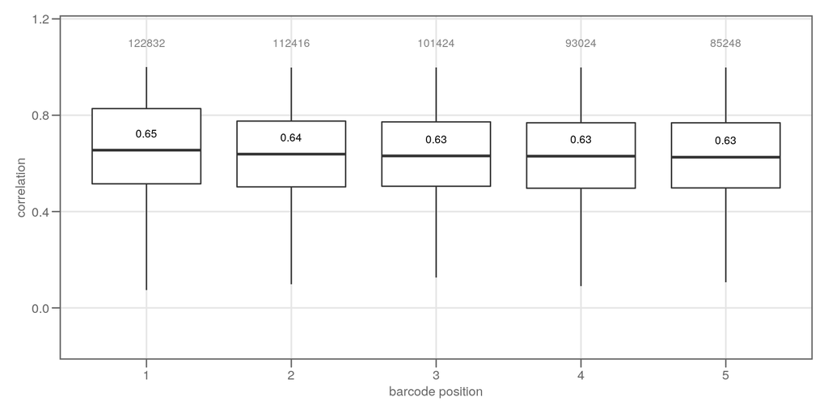

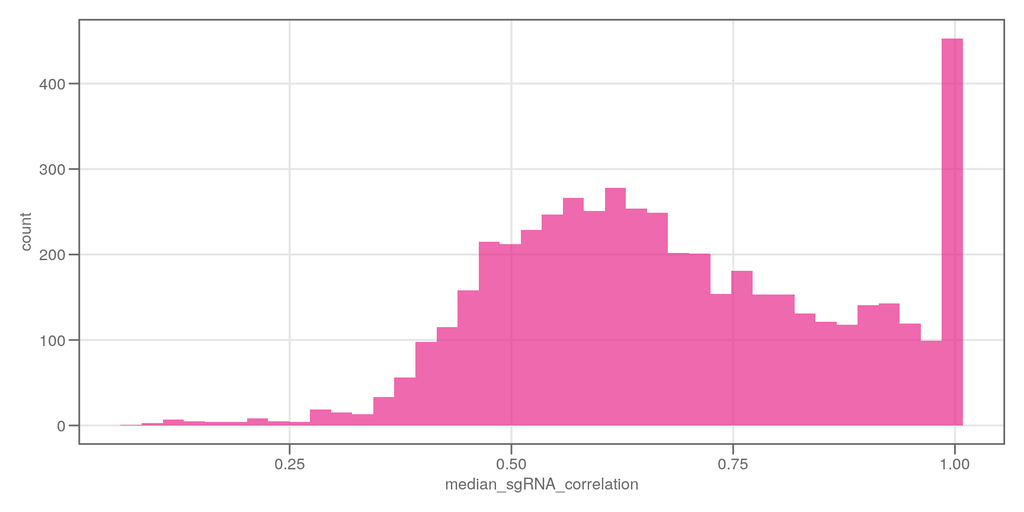

## 3.2 Barcode efficiency

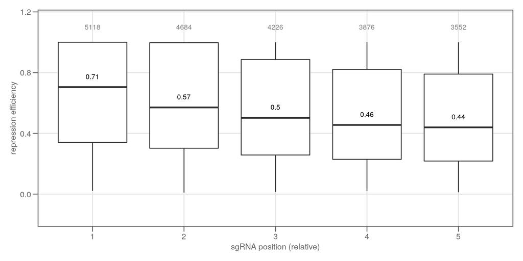

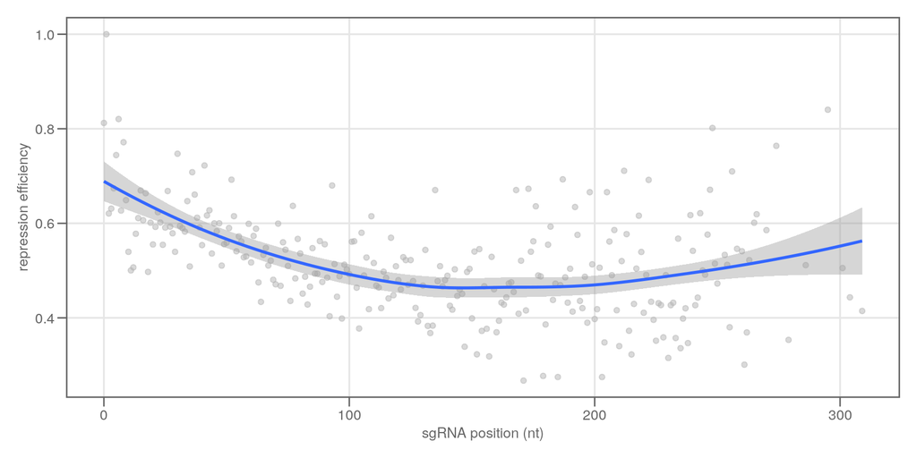

## 3.3 Barcode fitness

- This plot shows the global distribution of *barcode fitness score*
- Metric is the fitness of each barcode (mutant/sgRNA/…) in each condition
- Fitness is defined as the area under curve of log2 FC over time, normalized by time
- A *positive* fitness score means enrichment of the respective barcode, *negative* fitness means depletion
- This information is useful to show global differences between conditions, e.g. stronger vs weaker selection

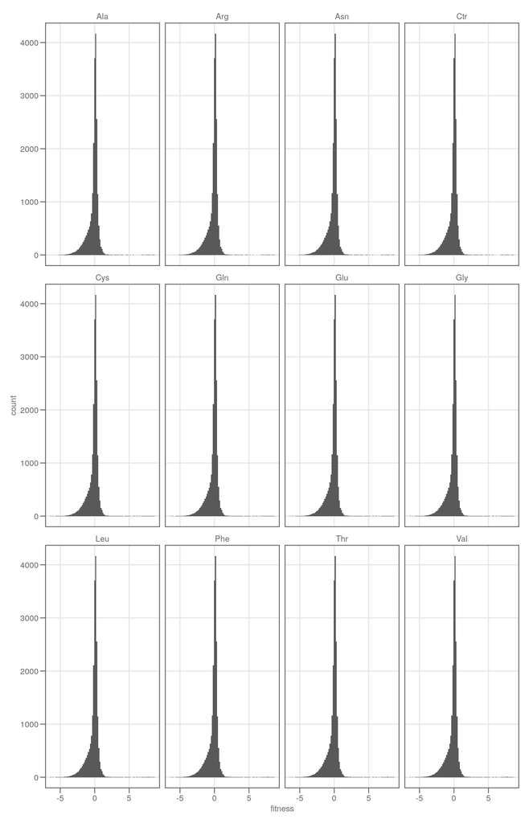

## 3.4 Gene fitness

- This plot shows the global distribution of gene fitness
- Metric is the weighted mean fitness of all barcodes
- This information is useful to show global differences between conditions, e.g. stronger vs weaker selection

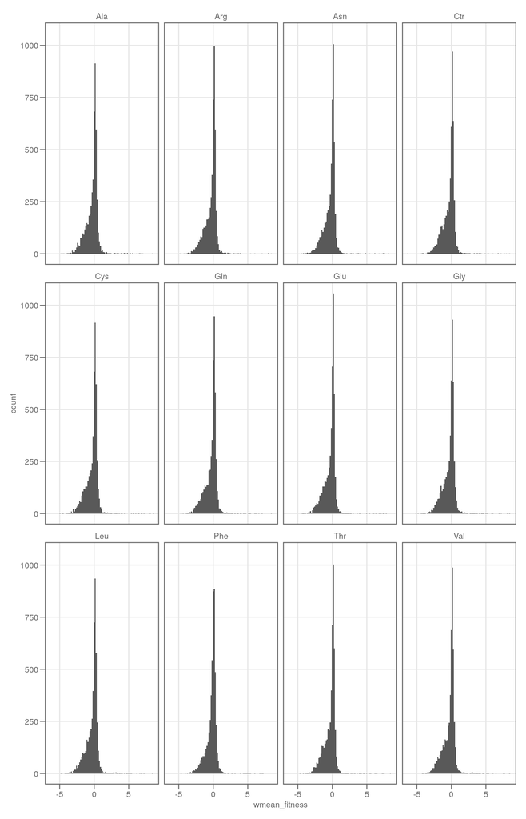

# 4 Report info

The template for this report is located in `./nf-core-crispriscreen/bin/fitness_summary.Rmd`.

Date: 2022-04-28

Author: Michael Jahn, PhD

Affilations:

- Science For Life Laboratory (KTH), Stockholm, Sweden
- Max-Planck-Unit for the Science of Pathogens, Berlin, Germany